# Tarea 1_ Regresión

Mariana Guzmán

Noviembre 2025

Cargamos las librerías y la información que se usará en el resto del archivo

```r
library(tidyverse)
library(corrplot)
#getwd()  Get working directory para saber en dónde estamos

# Set working directory
setwd("C:/Users/G18406/Documents/Curso_TS/Review_Estadística/Scripts")

# Carga el archivo "US_change_full.csv" dentro de la variable uschange
uschange <- read.csv("../data/US_change_full.csv")

# Mostrar los primeros 10 datos
head(uschange,10)
```

```
##          Date Consumption     Income Production    Savings Unemployment
## 1  01/01/1970   0.6185664  1.0448013 -2.4524855  5.2990141          0.9
## 2  01/04/1970   0.4519840  1.2256472 -0.5514595  7.7898938          0.5
## 3  01/07/1970   0.8728718  1.5851538 -0.3586518  7.4039841          0.5
## 4  01/10/1970  -0.2718479 -0.2395449 -2.1856909  1.1698982          0.7
## 5  01/01/1971   1.9013450  1.9759249  1.9097644  3.5356669         -0.1
## 6  01/04/1971   0.9148773  1.4459085  0.9015695  5.8747636         -0.1
## 7  01/07/1971   0.7941096  0.5211491  0.3080307 -0.4062353          0.1
## 8  01/10/1971   1.6456332  1.1591761  2.2913621 -1.4862589          0.0
## 9  01/01/1972   1.3111897  0.4568567  4.1542950 -4.2919722         -0.2
## 10 01/04/1972   1.8857779  1.0333893  1.8886727 -4.6921964         -0.1
```

```r
# Mostrar un resumen de lo que se incluye en el dataframe
summary(uschange)
```

```
##      Date            Consumption          Income          Production
##  Length:198         Min.   :-2.2778   Min.   :-4.0844   Min.   :-6.83604
##  Class :character   1st Qu.: 0.4175   1st Qu.: 0.3144   1st Qu.:-0.01078
##  Mode  :character   Median : 0.7767   Median : 0.7603   Median : 0.66609
##                     Mean   : 0.7425   Mean   : 0.7282   Mean   : 0.50708
##                     3rd Qu.: 1.0976   3rd Qu.: 1.1602   3rd Qu.: 1.29524
##                     Max.   : 2.3196   Max.   : 4.5219   Max.   : 4.15430
##     Savings         Unemployment
##  Min.   :-56.472   Min.   :-0.90000
##  1st Qu.: -4.049   1st Qu.:-0.20000
##  Median :  1.349   Median :-0.10000
##  Mean   :  1.392   Mean   : 0.00101
##  3rd Qu.:  6.341   3rd Qu.: 0.10000
##  Max.   : 41.608   Max.   : 1.40000
```

```r
# Calcula la varianza individual de la variable Consumo (Consumption)
var(uschange$Consumption)
```

```
## [1] 0.4068692
```

```r
# Elabora una Matriz de Varianzas/Covarianzas de variables numéricas
cov(uschange[,2:6])
```

```
##              Consumption      Income Production    Savings Unemployment
## Consumption    0.4068692  0.22037676  0.5134979  -1.958849  -0.12340208
## Income         0.2203768  0.81070679  0.3687138   7.759070  -0.07422323
## Production     0.5134979  0.36871378  2.3145044  -1.065057  -0.42889925
## Savings       -1.9588486  7.75907033 -1.0650568 143.192915   0.46572496
## Unemployment  -0.1234021 -0.07422323 -0.4288993   0.465725   0.13492283
```

```r
# Elabora una Matriz de correlación de variables numéricas
cor(uschange[,2:6])
```

```
##              Consumption     Income  Production     Savings Unemployment
## Consumption    1.0000000  0.3837130  0.52915422 -0.25663310   -0.5266867
## Income         0.3837130  1.0000000  0.26917112  0.72014014   -0.2244219
## Production     0.5291542  0.2691711  1.00000000 -0.05850365   -0.7675091
## Savings       -0.2566331  0.7201401 -0.05850365  1.00000000    0.1059561
## Unemployment  -0.5266867 -0.2244219 -0.76750914  0.10595611    1.0000000
```

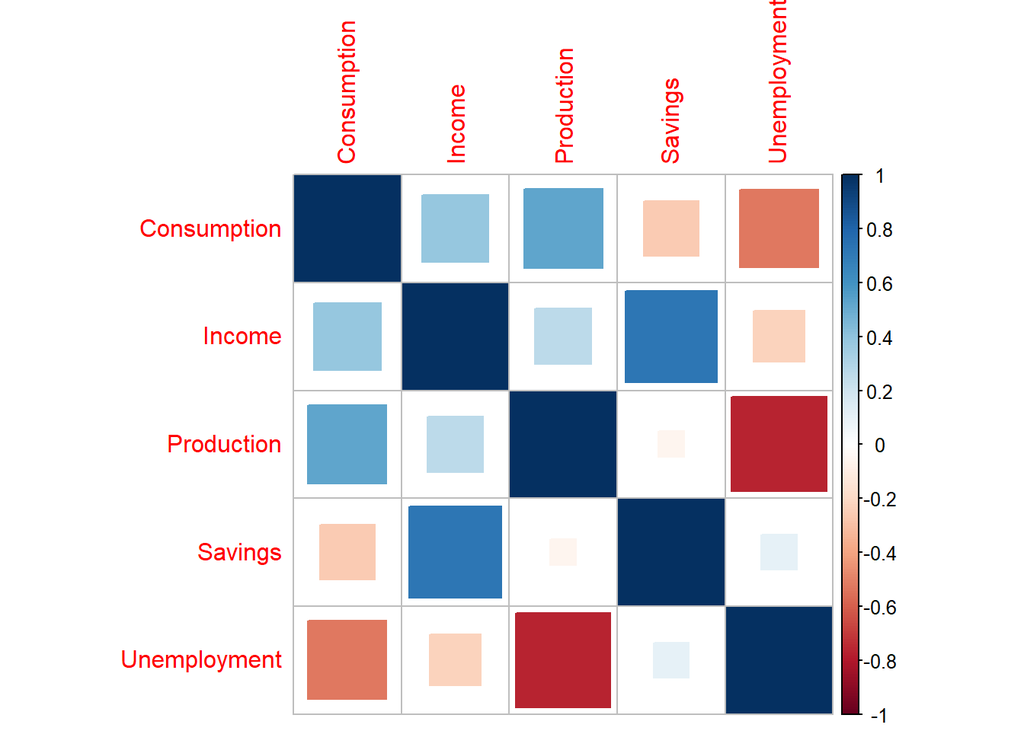

```r
# Grafica la matriz de correlaciones en un mapa de calor
# Utilizando la función corrplot de la librería con el mismo nombre
cor(uschange[,2:6]) %>% corrplot(method = "square")
```

Elegí la variable production al observar que tiene la mayor correlación con la variable de interés.

```r
# Ajusta un modelo de regresión lineal (simple) Y~X
# Y : Variable respuesta Consumption
# X : Variable explicativa (production)
# Y guardarla dentro de una variable llamada "reg"
reg <- lm(uschange$Consumption~uschange$Production)

# Analiza los resultados usando la función summary a la variable reg
summary(reg)
```

```
##
## Call:
## lm(formula = uschange$Consumption ~ uschange$Production)
##
## Residuals:
##      Min       1Q   Median       3Q      Max
## -1.94548 -0.33905 -0.02074  0.34122  1.72192
##
## Coefficients:
##                     Estimate Std. Error t value Pr(>|t|)
## (Intercept)          0.62998    0.04066  15.494  < 2e-16 ***
## uschange$Production  0.22186    0.02541   8.731 1.11e-15 ***
## ---
## Signif. codes:  0 '***' 0.001 '**' 0.01 '*' 0.05 '.' 0.1 ' ' 1
##
## Residual standard error: 0.5426 on 196 degrees of freedom
## Multiple R-squared:   0.28,  Adjusted R-squared:  0.2763
## F-statistic: 76.22 on 1 and 196 DF,  p-value: 1.108e-15
```

De los resultado de la regresión se observa que el intercepto y la pendiente son estadísticamente significativos al .1%. El coeficiente de determinación (R²) es de .28, por lo que se explica un 28% de la variabilidad de la variable dependiente (consumo).

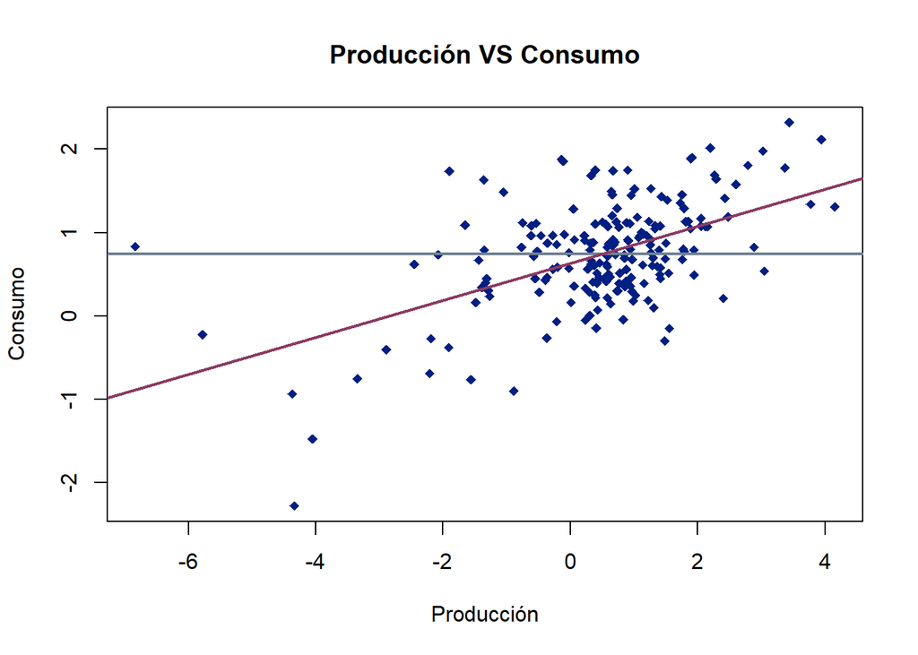

```r
# Elabora una gráfica de dispersión de Consumo (eje y)
# VS Variable explicativa (production) (eje x)
plot(x = uschange$Production,
     y = uschange$Consumption,                    # Coordenadas
     col = c("#001f82"),               # De qué color (puede ser más de uno e incluso ponerle "colors()")
     pch = 18,                            # Tipo de punto que se va a utilizar
     main = "Producción VS Consumo",     # Título del gráfico
     xlab = "Producción", # Nombre del eje x
     ylab = "Consumo")                    # Nombre del eje y
# Incorpora una línea que indique el modelo nulo (promedio de consumo)
# Y la línea de regresión
#Modelo nulo
abline(a = mean(uschange$Consumption), b = 0, col = "#708090", lwd = 2)
#línea de regresión
coefs <- coef(reg)
abline(a = coefs[1], b = coefs[2], col = "#8B3A62", lwd = 2)
```

```r
# Guarda las predicciones y residuales dentro del DF
# Y elabora una regresión de residuales ~ predicciones
uschange$pred_cons <- reg$fitted.values
uschange$res_cons <- reg$residuals

# Regresión de residuales
reg_res_cons <- lm(uschange$res_cons~uschange$pred_cons) # "~" Regresión de los residuales con base en predicciones
reg_res_cons
```

```
##
## Call:
## lm(formula = uschange$res_cons ~ uschange$pred_cons)
##
## Coefficients:
##        (Intercept)  uschange$pred_cons
##         -7.967e-17           9.667e-17
```

```r
summary(reg_res_cons)
```

```
##
## Call:
## lm(formula = uschange$res_cons ~ uschange$pred_cons)
##
## Residuals:
##      Min       1Q   Median       3Q      Max
## -1.94548 -0.33905 -0.02074  0.34122  1.72192
##
## Coefficients:
##                      Estimate Std. Error t value Pr(>|t|)
## (Intercept)        -7.967e-17  9.338e-02       0        1
## uschange$pred_cons  9.667e-17  1.145e-01       0        1
##
## Residual standard error: 0.5426 on 196 degrees of freedom
## Multiple R-squared:  1.323e-32,  Adjusted R-squared:  -0.005102
## F-statistic: 2.593e-30 on 1 and 196 DF,  p-value: 1
```

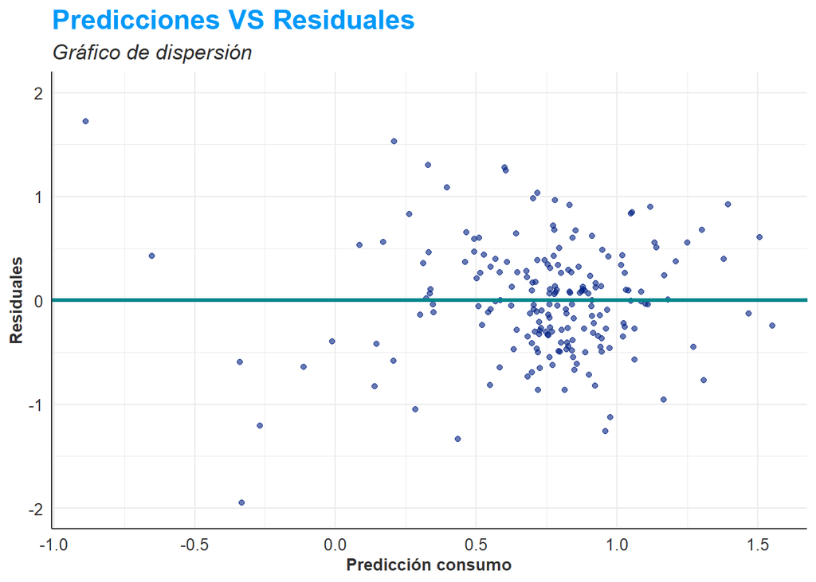

```r
# Elabora el gráfico de residuales VS predicciones
# Incluyendo la línea de regresión
uschange %>% ggplot(aes(x = uschange$pred_cons, y = uschange$res_cons)) + geom_point(alpha = 0.6, color = "#001F82") +
  geom_abline(intercept = coef(reg_res_cons)[1], slope = coef(reg_res_cons)[2], color = "#00868B", size = 1.2)+
  labs(title = "Predicciones VS Residuales",
       subtitle = "Gráfico de dispersión",
       x = "Predicción consumo",
       y = "Residuales") +
  coord_cartesian(ylim = c(-2, 2)) +
  theme_minimal() +
  theme(
    plot.title = element_text(color = "#0099F8",
                              size = 17,
                              face = "bold"),
    plot.subtitle = element_text(color = "#303030", size = 13, face = "italic"),
    axis.title = element_text(color = "#303030",
                              size = 10,
                              face = "bold"),
    axis.text = element_text(color = "#303030", size = 10),
    axis.line = element_line(color = "#303030")
  )
```

De la gráfica de predicciones vs residuales se esperaría ver que los residuales se encuentren cerca del cero, lo que se cumple en la gráfica. Del mismo modo, la regresión nos da un intercepto y pendiente muy cercano a cero.

```r
# Regresión múltiple
# Elabora un modelo de regresión múltiple
# Cuya variable (Y) dependiente sea Consumo
# Utilizando dos variables explicativas (producción / desempleo)

reg_mult <-lm(uschange$Consumption~uschange$Production + uschange$Unemployment)

# Analiza los resultados utilizando la función summary
summary(reg_mult)
```

```
##
## Call:
## lm(formula = uschange$Consumption ~ uschange$Production + uschange$Unemployment)
##
## Residuals:
##      Min       1Q   Median       3Q      Max
## -1.74107 -0.33850  0.00788  0.25512  1.74140
##
## Coefficients:
##                       Estimate Std. Error t value Pr(>|t|)
## (Intercept)            0.67837    0.04257  15.935  < 2e-16 ***
## uschange$Production    0.12745    0.03875   3.289  0.00119 **
## uschange$Unemployment -0.50946    0.16051  -3.174  0.00175 **
## ---
## Signif. codes:  0 '***' 0.001 '**' 0.01 '*' 0.05 '.' 0.1 ' ' 1
##
## Residual standard error: 0.5305 on 195 degrees of freedom
## Multiple R-squared:  0.3154, Adjusted R-squared:  0.3084
## F-statistic: 44.91 on 2 and 195 DF,  p-value: < 2.2e-16
```

Para la regresión múltiple se agregó el desempleo por tener la segunda correlación más fuerte con el consumo. De la regresión múltiple se observa que el intercepto es estadísticamente significativo al .1% y los coeficientes son estadísticamente significativos al 1%. Se obtuvo un coeficiente de determinación (R²) de 0.31 y una R² ajustada de 0.30, por lo que el modelo múltiple explica una mayor proporción de la variabilidad del consumo en comparación con el modelo simple.

```r
# Guarda las predicciones y residuales dentro del DF
uschange$pred_cons_mult <-reg_mult$fitted.values
uschange$res_cons_mult <- reg_mult$residuals

# Y elabora una regresión de residuales ~ predicciones
# Para el modelo múltiple
reg_res_mult <- lm(uschange$res_cons_mult~uschange$pred_cons_mult) # "~" Regresión de los residuales con base en predicciones
reg_res_mult
```

```
##
## Call:
## lm(formula = uschange$res_cons_mult ~ uschange$pred_cons_mult)
##
## Coefficients:
##             (Intercept)  uschange$pred_cons_mult
##              -5.069e-16                5.659e-16
```

```r
summary(reg_res_mult)
```

```
##
## Call:
## lm(formula = uschange$res_cons_mult ~ uschange$pred_cons_mult)
##
## Residuals:
##      Min       1Q   Median       3Q      Max
## -1.74107 -0.33850  0.00788  0.25512  1.74140
##
## Coefficients:
##                           Estimate Std. Error t value Pr(>|t|)
## (Intercept)             -5.069e-16  8.672e-02       0        1
## uschange$pred_cons_mult  5.659e-16  1.052e-01       0        1
##
## Residual standard error: 0.5291 on 196 degrees of freedom
## Multiple R-squared:  1.49e-31,   Adjusted R-squared:  -0.005102
## F-statistic: 2.921e-29 on 1 and 196 DF,  p-value: 1
```

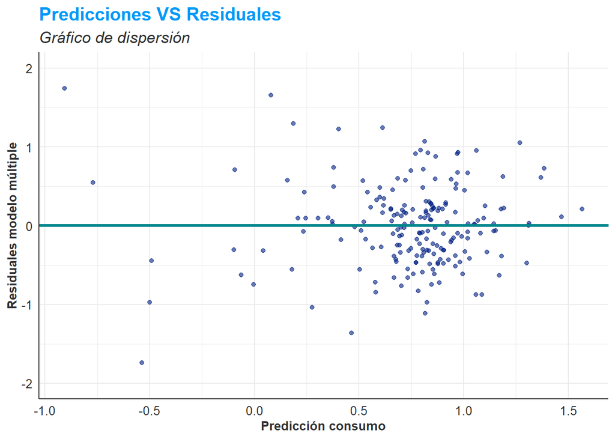

```r
# Elabora un Gráfico de residuales contra predicciones para el modelo múltiple

uschange %>% ggplot(aes(x = uschange$pred_cons_mult, y = uschange$res_cons_mult)) + geom_point(alpha = 0.6, color = "#001F82") +
  geom_abline(intercept = coef(reg_res_mult)[1], slope = coef(reg_res_mult)[2], color = "#00868B", size = 1.2)+
  labs(title = "Predicciones VS Residuales",
       subtitle = "Gráfico de dispersión",
       x = "Predicción consumo",
       y = "Residuales modelo múltiple") +
  coord_cartesian(ylim = c(-2, 2)) +
  theme_minimal() +
  theme(
    plot.title = element_text(color = "#0099F8",
                              size = 15,
                              face = "bold"),
    plot.subtitle = element_text(color = "#303030", size = 13, face = "italic"),
    axis.title = element_text(color = "#303030",
                              size = 10,
                              face = "bold"),
    axis.text = element_text(color = "#303030", size = 10),
    axis.line = element_line(color = "#303030")
  )
```

De la gráfica de predicciones vs residuales se esperaría ver que los residuales se encuentren cerca del cero, lo que se cumple en la gráfica. Del mismo modo, la regresión nos da un intercepto y pendiente muy cercano a cero.

```r
# Realiza una comparación de ambos modelos
# Utilizando criterios de información
library(broom)
glance(reg)
```

```
## # A tibble: 1 × 12
##   r.squared adj.r.squared sigma statistic  p.value    df logLik   AIC   BIC
##       <dbl>         <dbl> <dbl>     <dbl>    <dbl> <dbl>  <dbl> <dbl> <dbl>
## 1     0.280         0.276 0.543      76.2 1.11e-15     1  -159.  324.  334.
## # ℹ 3 more variables: deviance <dbl>, df.residual <int>, nobs <int>
```

```r
glance(reg_mult)
```

```
## # A tibble: 1 × 12
##   r.squared adj.r.squared sigma statistic  p.value    df logLik   AIC   BIC
##       <dbl>         <dbl> <dbl>     <dbl>    <dbl> <dbl>  <dbl> <dbl> <dbl>
## 1     0.315         0.308 0.530      44.9 9.05e-17     2  -154.  316.  329.
## # ℹ 3 more variables: deviance <dbl>, df.residual <int>, nobs <int>
```

Elegiría el modelo mútiple porque tiene una mayor R² y R² ajustada, mientras que que el AIC y BIC son menores en este modelo, que es lo que estamos buscando.